# Assignment 2: Hand Gesture Recognition [50 Pt]

### Part (iii) “Overfit” to a Small Dataset - [1pt MODEL]

One way to sanity check our neural network model and training code is to check whether the model is capable of “overfitting” or “memorizing” a small dataset. A properly constructed CNN with correct training code should be able to memorize the answers to a small number of images quickly.

Construct a small dataset (e.g. just the images that you have collected). Then show that your model and training code is capable of memorizing the labels of this small data set.

With a large batch size (e.g. the entire small dataset) and learning rate that is not too high, you should be able to obtain a 100% training accuracy on that small dataset relatively quickly (within 200 iterations).

```python
torch.cuda.empty_cache()
```

```
CUDA is available!  Training on GPU ...
Epoch 1:  Train loss: 0.08140600169146503 |Train accuracy: 0.1111111111111111, Validation accuracy: 0.1111111111111111
Epoch 2:  Train loss: 0.08135191599527995 |Train accuracy: 0.1111111111111111, Validation accuracy: 0.1111111111111111
Epoch 3:  Train loss: 0.08126937018500434 |Train accuracy: 0.18518518518518517, Validation accuracy: 0.18518518518518517
Epoch 4:  Train loss: 0.0811673535241021 |Train accuracy: 0.2222222222222222, Validation accuracy: 0.2222222222222222
Epoch 5:  Train loss: 0.08104191886054145 |Train accuracy: 0.2222222222222222, Validation accuracy: 0.2222222222222222
Epoch 6:  Train loss: 0.08090716821176035 |Train accuracy: 0.2222222222222222, Validation accuracy: 0.2222222222222222
Epoch 7:  Train loss: 0.08073791751155147 |Train accuracy: 0.1111111111111111, Validation accuracy: 0.1111111111111111
Epoch 8:  Train loss: 0.08056036631266277 |Train accuracy: 0.1111111111111111, Validation accuracy: 0.1111111111111111
Epoch 9:  Train loss: 0.08035465523048684 |Train accuracy: 0.18518518518518517, Validation accuracy: 0.18518518518518517
Epoch 10:  Train loss: 0.08012217062490957 |Train accuracy: 0.2222222222222222, Validation accuracy: 0.2222222222222222
Epoch 11:  Train loss: 0.07989666197035047 |Train accuracy: 0.2222222222222222, Validation accuracy: 0.2222222222222222
Epoch 12:  Train loss: 0.07959721706531665 |Train accuracy: 0.4444444444444444, Validation accuracy: 0.4444444444444444
Epoch 13:  Train loss: 0.07927450427302608 |Train accuracy: 0.4444444444444444, Validation accuracy: 0.4444444444444444
Epoch 14:  Train loss: 0.07895418449684426 |Train accuracy: 0.4444444444444444, Validation accuracy: 0.4444444444444444
Epoch 15:  Train loss: 0.07856431713810673 |Train accuracy: 0.4444444444444444, Validation accuracy: 0.4444444444444444
Epoch 16:  Train loss: 0.07818423377143012 |Train accuracy: 0.6666666666666666, Validation accuracy: 0.6666666666666666
Epoch 17:  Train loss: 0.07767299369529441 |Train accuracy: 0.5555555555555556, Validation accuracy: 0.5555555555555556
Epoch 18:  Train loss: 0.07717732146934227 |Train accuracy: 0.5555555555555556, Validation accuracy: 0.5555555555555556
Epoch 19:  Train loss: 0.07662847306993273 |Train accuracy: 0.5555555555555556, Validation accuracy: 0.5555555555555556
Epoch 20:  Train loss: 0.07596084806654188 |Train accuracy: 0.5925925925925926, Validation accuracy: 0.5925925925925926
Epoch 21:  Train loss: 0.07516074180603027 |Train accuracy: 0.8518518518518519, Validation accuracy: 0.8518518518518519
Epoch 22:  Train loss: 0.07421259526853208 |Train accuracy: 1.0, Validation accuracy: 1.0
Epoch 23:  Train loss: 0.07317349645826551 |Train accuracy: 0.8888888888888888, Validation accuracy: 0.8888888888888888
Epoch 24:  Train loss: 0.0719607362040767 |Train accuracy: 0.8888888888888888, Validation accuracy: 0.8888888888888888
Epoch 25:  Train loss: 0.07061911070788349 |Train accuracy: 0.8888888888888888, Validation accuracy: 0.8888888888888888
Epoch 26:  Train loss: 0.0689486132727729 |Train accuracy: 0.9629629629629629, Validation accuracy: 0.9629629629629629
Epoch 27:  Train loss: 0.06689827088956479 |Train accuracy: 1.0, Validation accuracy: 1.0
Epoch 28:  Train loss: 0.06463503837585449 |Train accuracy: 0.9629629629629629, Validation accuracy: 0.9629629629629629
Epoch 29:  Train loss: 0.061852614084879555 |Train accuracy: 1.0, Validation accuracy: 1.0
Epoch 30:  Train loss: 0.058718570956477416 |Train accuracy: 1.0, Validation accuracy: 1.0
Epoch 31:  Train loss: 0.05476412949738679 |Train accuracy: 1.0, Validation accuracy: 1.0
Epoch 32:  Train loss: 0.05036823396329527 |Train accuracy: 1.0, Validation accuracy: 1.0
```

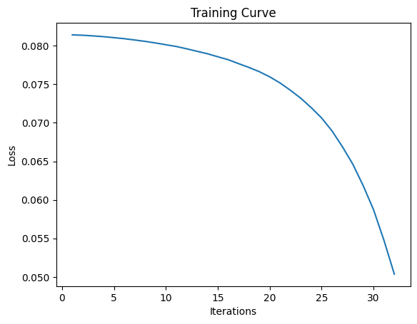

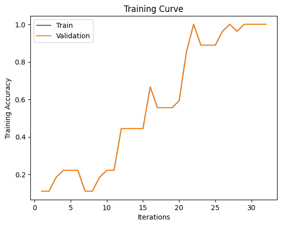

```
Final Training Accuracy: 1.0
Final Validation Accuracy: 1.0
```

```
(1.0, 1.0)
```

```python
small_data = datasets.ImageFolder('/content/drive/MyDrive/Colab Notebooks/mie1517/a2/yuting_small_data', transform=transforms.ToTensor())
small_train_loader = torch.utils.data.DataLoader(small_data, batch_size=27, num_workers=0, shuffle=True)
small_model = CNNClassifier()
# Training model
use_cuda = True
if use_cuda and torch.cuda.is_available():
  small_model.cuda()
  print('CUDA is available!  Training on GPU ...')
else:
  print('CUDA is not available.  Training on CPU ...')

train(small_model, small_train_loader, small_train_loader, batch_size=27, lr=0.005, num_epochs=32)
```

## Part 3. Hyperparameter Search [7pt]

### Part (i) - [2pt EXPLORATORY]

List 3 hyperparameters that you think are most worth tuning. Choose at least one hyperparameter related to the model architecture.

```python
'''
PROVIDE YOUR ANSWER BELOW

batch size
learning rate
kernel size

'''
```

```
'\nPROVIDE YOUR ANSWER BELOW\n\nbatch size\nlearning rate \nkernel size\n\n'
```

### Part (ii) - [1pt MODEL]

Tune the hyperparameters you listed in Part (i), trying as many values as you need to until you feel satisfied that you are getting a good model. Plot the training curve of at least 4 different hyperparameter settings.

```
Model 1 with hyperparameters: batch size: 128, learning rate: 0.01, layer 3 out channels: 3
CUDA is available!  Training on GPU ...
Epoch 1:  Train loss: 0.008351979777216911 |Train accuracy: 0.3848531684698609, Validation accuracy: 0.38333333333333336
Epoch 2:  Train loss: 0.022254938259720802 |Train accuracy: 0.6625450798557445, Validation accuracy: 0.6541666666666667
Epoch 3:  Train loss: 0.014231647364795208 |Train accuracy: 0.6831530139103554, Validation accuracy: 0.7041666666666667
Epoch 4:  Train loss: 0.028110411018133163 |Train accuracy: 0.20041215868109222, Validation accuracy: 0.2125
Epoch 5:  Train loss: 0.013617554679512978 |Train accuracy: 0.6754250386398764, Validation accuracy: 0.65
Epoch 6:  Train loss: 1.0896398094928372e-07 |Train accuracy: 0.7537351880473983, Validation accuracy: 0.7166666666666667
Epoch 7:  Train loss: 0.01566920429468155 |Train accuracy: 0.7800103039670273, Validation accuracy: 0.7625
Epoch 8:  Train loss: 0.024463241919875145 |Train accuracy: 0.6439979392065945, Validation accuracy: 0.5708333333333333
Epoch 9:  Train loss: 4.78087849842268e-06 |Train accuracy: 0.7805255023183926, Validation accuracy: 0.75
Epoch 10:  Train loss: 0.00010113334428751841 |Train accuracy: 0.7017001545595054, Validation accuracy: 0.6208333333333333
Epoch 11:  Train loss: 9.866910841083154e-05 |Train accuracy: 0.8284389489953632, Validation accuracy: 0.7625
Epoch 12:  Train loss: 0.00010648668830981478 |Train accuracy: 0.8274085522926327, Validation accuracy: 0.7291666666666666
Epoch 13:  Train loss: 7.916202093838365e-08 |Train accuracy: 0.9309634209170531, Validation accuracy: 0.7791666666666667
Epoch 14:  Train loss: 0.0015876168617978692 |Train accuracy: 0.9407521895929933, Validation accuracy: 0.8
Epoch 15:  Train loss: 0.00011528393224580213 |Train accuracy: 0.9716640906749099, Validation accuracy: 0.7916666666666666
Epoch 16:  Train loss: 3.580911652534269e-05 |Train accuracy: 0.9716640906749099, Validation accuracy: 0.8083333333333333
Epoch 17:  Train loss: 2.205422606493812e-05 |Train accuracy: 0.9654817104585265, Validation accuracy: 0.7791666666666667
Epoch 18:  Train loss: 6.968771685933461e-06 |Train accuracy: 0.9788768675940237, Validation accuracy: 0.825
Epoch 19:  Train loss: 3.1221006793202832e-06 |Train accuracy: 0.9469345698093766, Validation accuracy: 0.7625
Epoch 20:  Train loss: 0.00013952628069091588 |Train accuracy: 0.9489953632148377, Validation accuracy: 0.7958333333333333
Epoch 21:  Train loss: 5.587933671336032e-09 |Train accuracy: 0.9824832560535807, Validation accuracy: 0.775
Epoch 22:  Train loss: 0.0 |Train accuracy: 0.994332818134982, Validation accuracy: 0.8
Epoch 23:  Train loss: 6.984888045735715e-08 |Train accuracy: 0.9979392065945389, Validation accuracy: 0.7958333333333333
Epoch 24:  Train loss: 0.0 |Train accuracy: 0.9860896445131375, Validation accuracy: 0.7666666666666667
Epoch 25:  Train loss: 3.203684002528462e-07 |Train accuracy: 0.9933024214322514, Validation accuracy: 0.8083333333333333
Epoch 26:  Train loss: 0.0 |Train accuracy: 0.9984544049459042, Validation accuracy: 0.7791666666666667
Epoch 27:  Train loss: 9.313225191043273e-10 |Train accuracy: 0.9994848016486347, Validation accuracy: 0.8083333333333333
Epoch 28:  Train loss: 1.7427015336579643e-05 |Train accuracy: 0.9994848016486347, Validation accuracy: 0.7916666666666666
Epoch 29:  Train loss: 9.313225191043273e-10 |Train accuracy: 1.0, Validation accuracy: 0.7958333333333333
Epoch 30:  Train loss: 1.124414393416373e-05 |Train accuracy: 0.9994848016486347, Validation accuracy: 0.7916666666666666
Epoch 31:  Train loss: 5.0291255604406615e-08 |Train accuracy: 1.0, Validation accuracy: 0.8041666666666667
Epoch 32:  Train loss: 1.4527281564369332e-06 |Train accuracy: 1.0, Validation accuracy: 0.8041666666666667
```

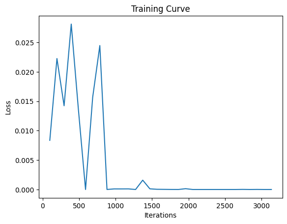

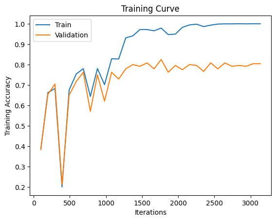

```
Final Training Accuracy: 1.0
Final Validation Accuracy: 0.8041666666666667
Model 2 with hyperparameters: batch size: 512, learning rate: 0.01, layer 3 out channels: 3
CUDA is available!  Training on GPU ...
Epoch 1:  Train loss: 0.001250597182661295 |Train accuracy: 0.5404430705821741, Validation accuracy: 0.5458333333333333
Epoch 2:  Train loss: 1.7112538444052916e-06 |Train accuracy: 0.6671818650180319, Validation accuracy: 0.6333333333333333
Epoch 3:  Train loss: 0.0002874837373383343 |Train accuracy: 0.6439979392065945, Validation accuracy: 0.6083333333333333
Epoch 4:  Train loss: 0.0003848366905003786 |Train accuracy: 0.7104585265327151, Validation accuracy: 0.6958333333333333
Epoch 5:  Train loss: 0.0009389633778482676 |Train accuracy: 0.6439979392065945, Validation accuracy: 0.6291666666666667
Epoch 6:  Train loss: 0.0027628608513623476 |Train accuracy: 0.7779495105615662, Validation accuracy: 0.7291666666666666
Epoch 7:  Train loss: 0.00023425891413353384 |Train accuracy: 0.8325605358062854, Validation accuracy: 0.75
Epoch 8:  Train loss: 8.799539500614628e-06 |Train accuracy: 0.872746007212777, Validation accuracy: 0.7666666666666667
Epoch 9:  Train loss: 0.00019475295266602188 |Train accuracy: 0.9160226687274601, Validation accuracy: 0.7916666666666666
Epoch 10:  Train loss: 2.9186785468482412e-06 |Train accuracy: 0.9562081401339516, Validation accuracy: 0.8041666666666667
Epoch 11:  Train loss: 7.706542248797632e-08 |Train accuracy: 0.9283874291602267, Validation accuracy: 0.775
Epoch 12:  Train loss: 6.832383974142431e-07 |Train accuracy: 0.9783616692426584, Validation accuracy: 0.8166666666666667
Epoch 13:  Train loss: 0.00014882780669722706 |Train accuracy: 0.9634209170530654, Validation accuracy: 0.7916666666666666
Epoch 14:  Train loss: 2.182963953600847e-06 |Train accuracy: 0.9917568263781555, Validation accuracy: 0.8
Epoch 15:  Train loss: 3.163912083437026e-07 |Train accuracy: 0.9732096857290057, Validation accuracy: 0.8
Epoch 16:  Train loss: 2.582944262030651e-06 |Train accuracy: 0.9927872230808862, Validation accuracy: 0.8083333333333333
Epoch 17:  Train loss: 8.102338000526288e-08 |Train accuracy: 0.9958784131890778, Validation accuracy: 0.8041666666666667
Epoch 18:  Train loss: 1.3604212654172443e-06 |Train accuracy: 0.9989696032972695, Validation accuracy: 0.8333333333333334
Epoch 19:  Train loss: 1.6298138394432726e-09 |Train accuracy: 0.9994848016486347, Validation accuracy: 0.825
Epoch 20:  Train loss: 0.0 |Train accuracy: 1.0, Validation accuracy: 0.8291666666666667
Epoch 21:  Train loss: 0.0 |Train accuracy: 1.0, Validation accuracy: 0.8375
Epoch 22:  Train loss: 0.00010717040277086198 |Train accuracy: 1.0, Validation accuracy: 0.8375
Epoch 23:  Train loss: 0.0 |Train accuracy: 0.9994848016486347, Validation accuracy: 0.8375
Epoch 24:  Train loss: 0.0 |Train accuracy: 1.0, Validation accuracy: 0.8333333333333334
Epoch 25:  Train loss: 0.0 |Train accuracy: 1.0, Validation accuracy: 0.8375
Epoch 26:  Train loss: 0.0 |Train accuracy: 1.0, Validation accuracy: 0.8375
Epoch 27:  Train loss: 0.0 |Train accuracy: 1.0, Validation accuracy: 0.8375
Epoch 28:  Train loss: 2.1691605070373043e-05 |Train accuracy: 1.0, Validation accuracy: 0.8375
Epoch 29:  Train loss: 4.629468548955629e-06 |Train accuracy: 1.0, Validation accuracy: 0.8375
Epoch 30:  Train loss: 2.2722949211129162e-07 |Train accuracy: 1.0, Validation accuracy: 0.8375
Epoch 31:  Train loss: 0.0 |Train accuracy: 1.0, Validation accuracy: 0.8375
Epoch 32:  Train loss: 4.6566123179658803e-10 |Train accuracy: 1.0, Validation accuracy: 0.8375
```

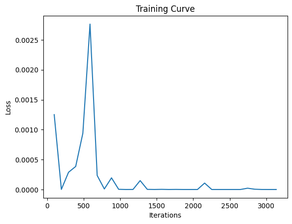

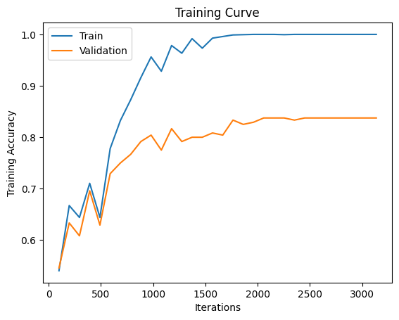

```
Final Training Accuracy: 1.0
Final Validation Accuracy: 0.8375
Model 3 with hyperparameters: batch size: 128, learning rate: 0.005, layer 3 out channels: 3
CUDA is available!  Training on GPU ...
Epoch 1:  Train loss: 0.0180768184363842 |Train accuracy: 0.18031942297784648, Validation accuracy: 0.19583333333333333
Epoch 2:  Train loss: 0.0014800664503127337 |Train accuracy: 0.4348274085522926, Validation accuracy: 0.4666666666666667
Epoch 3:  Train loss: 0.006246275268495083 |Train accuracy: 0.5342606903657908, Validation accuracy: 0.5708333333333333
Epoch 4:  Train loss: 0.010164068080484867 |Train accuracy: 0.6661514683153014, Validation accuracy: 0.675
Epoch 5:  Train loss: 0.0018213486764580011 |Train accuracy: 0.6913961875321999, Validation accuracy: 0.7083333333333334
Epoch 6:  Train loss: 0.007143037393689156 |Train accuracy: 0.7460072127769191, Validation accuracy: 0.725
Epoch 7:  Train loss: 0.020415522158145905 |Train accuracy: 0.6831530139103554, Validation accuracy: 0.6625
Epoch 8:  Train loss: 0.002024381887167692 |Train accuracy: 0.7279752704791345, Validation accuracy: 0.7375
Epoch 9:  Train loss: 0.0003955321153625846 |Train accuracy: 0.7666151468315301, Validation accuracy: 0.7166666666666667
Epoch 10:  Train loss: 1.75627690168767e-06 |Train accuracy: 0.8227717671303452, Validation accuracy: 0.7416666666666667
Epoch 11:  Train loss: 2.024432887992589e-06 |Train accuracy: 0.7964966512107161, Validation accuracy: 0.725
Epoch 12:  Train loss: 0.004955152049660683 |Train accuracy: 0.8490468830499742, Validation accuracy: 0.7458333333333333
Epoch 13:  Train loss: 0.00013316923286765814 |Train accuracy: 0.8475012879958784, Validation accuracy: 0.725
Epoch 14:  Train loss: 0.00013706223398912698 |Train accuracy: 0.8871715610510046, Validation accuracy: 0.7708333333333334
Epoch 15:  Train loss: 9.834162483457476e-06 |Train accuracy: 0.9356002060793406, Validation accuracy: 0.7875
Epoch 16:  Train loss: 0.0008324336376972497 |Train accuracy: 0.9428129829984544, Validation accuracy: 0.8
Epoch 17:  Train loss: 1.4407306480279658e-05 |Train accuracy: 0.9623905203503349, Validation accuracy: 0.775
Epoch 18:  Train loss: 5.8993915445171297e-05 |Train accuracy: 0.9623905203503349, Validation accuracy: 0.7958333333333333
Epoch 19:  Train loss: 1.3782358792013838e-06 |Train accuracy: 0.9670273055126224, Validation accuracy: 0.8
Epoch 20:  Train loss: 0.0 |Train accuracy: 0.9680577022153529, Validation accuracy: 0.8166666666666667
Epoch 21:  Train loss: 0.000559200590942055 |Train accuracy: 0.9829984544049459, Validation accuracy: 0.8291666666666667
Epoch 22:  Train loss: 4.0325227246285067e-07 |Train accuracy: 0.9938176197836167, Validation accuracy: 0.8208333333333333
Epoch 23:  Train loss: 2.2963040464674123e-06 |Train accuracy: 0.9994848016486347, Validation accuracy: 0.8333333333333334
Epoch 24:  Train loss: 2.8093065338907763e-05 |Train accuracy: 0.9994848016486347, Validation accuracy: 0.8416666666666667
Epoch 25:  Train loss: 0.0 |Train accuracy: 1.0, Validation accuracy: 0.8375
Epoch 26:  Train loss: 4.462700235308148e-05 |Train accuracy: 1.0, Validation accuracy: 0.8375
Epoch 27:  Train loss: 2.2351422046540392e-07 |Train accuracy: 1.0, Validation accuracy: 0.8416666666666667
Epoch 28:  Train loss: 0.0 |Train accuracy: 1.0, Validation accuracy: 0.8375
Epoch 29:  Train loss: 0.0 |Train accuracy: 1.0, Validation accuracy: 0.8375
Epoch 30:  Train loss: 1.3038505386475663e-08 |Train accuracy: 1.0, Validation accuracy: 0.8375
Epoch 31:  Train loss: 4.2983148887287825e-05 |Train accuracy: 1.0, Validation accuracy: 0.8375
Epoch 32:  Train loss: 4.7358276788145304e-05 |Train accuracy: 1.0, Validation accuracy: 0.8375
```

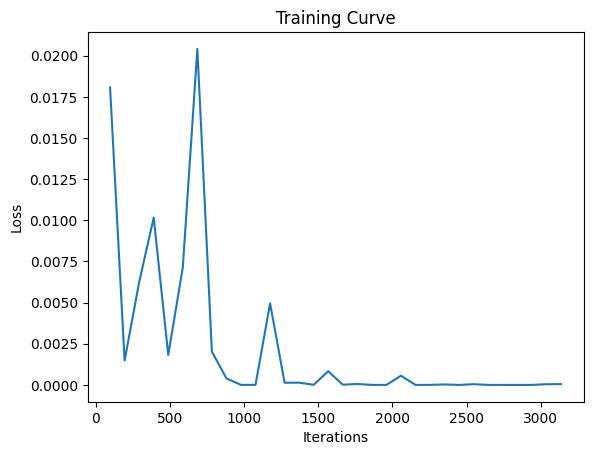

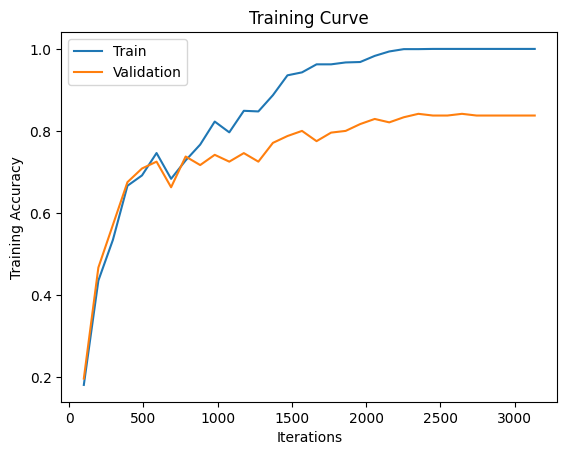

```
Final Training Accuracy: 1.0
Final Validation Accuracy: 0.8375
Model 4 with hyperparameters: batch size: 512, learning rate: 0.005, layer 3 out channels: 3
CUDA is available!  Training on GPU ...
Epoch 1:  Train loss: 0.002347134053707123 |Train accuracy: 0.21844410097887687, Validation accuracy: 0.2125
Epoch 2:  Train loss: 0.000877135491464287 |Train accuracy: 0.5677485832045337, Validation accuracy: 0.6166666666666667
Epoch 3:  Train loss: 0.0018328827572986484 |Train accuracy: 0.6512107161257084, Validation accuracy: 0.6541666666666667
Epoch 4:  Train loss: 0.00016397271247114986 |Train accuracy: 0.7424008243173622, Validation accuracy: 0.7416666666666667
Epoch 5:  Train loss: 0.0005724024958908558 |Train accuracy: 0.729005667181865, Validation accuracy: 0.7
Epoch 6:  Train loss: 0.004147830884903669 |Train accuracy: 0.7774343122102009, Validation accuracy: 0.7458333333333333
Epoch 7:  Train loss: 2.0127517927903682e-05 |Train accuracy: 0.7630087583719732, Validation accuracy: 0.7125
Epoch 8:  Train loss: 0.0004132226458750665 |Train accuracy: 0.8413189077794951, Validation accuracy: 0.7791666666666667
Epoch 9:  Train loss: 0.0015880204737186432 |Train accuracy: 0.8737764039155075, Validation accuracy: 0.8041666666666667
Epoch 10:  Train loss: 5.338587652659044e-05 |Train accuracy: 0.8428645028335909, Validation accuracy: 0.775
Epoch 11:  Train loss: 0.0010573230683803558 |Train accuracy: 0.8763523956723338, Validation accuracy: 0.7708333333333334
Epoch 12:  Train loss: 0.0001257515250472352 |Train accuracy: 0.8938691396187533, Validation accuracy: 0.7875
Epoch 13:  Train loss: 0.008619618602097034 |Train accuracy: 0.7156105100463679, Validation accuracy: 0.5791666666666667
Epoch 14:  Train loss: 0.002410709159448743 |Train accuracy: 0.6723338485316847, Validation accuracy: 0.625
Epoch 15:  Train loss: 0.005943705327808857 |Train accuracy: 0.7872230808861411, Validation accuracy: 0.7208333333333333
Epoch 16:  Train loss: 0.000873225973919034 |Train accuracy: 0.8845955692941783, Validation accuracy: 0.7791666666666667
Epoch 17:  Train loss: 3.1252700864570215e-05 |Train accuracy: 0.8964451313755796, Validation accuracy: 0.7625
Epoch 18:  Train loss: 0.00033735792385414243 |Train accuracy: 0.9335394126738794, Validation accuracy: 0.7916666666666666
Epoch 19:  Train loss: 2.4536573164368747e-06 |Train accuracy: 0.8923235445646573, Validation accuracy: 0.75
Epoch 20:  Train loss: 1.2496678891693591e-06 |Train accuracy: 0.9572385368366821, Validation accuracy: 0.8
Epoch 21:  Train loss: 8.758513104112353e-06 |Train accuracy: 0.9654817104585265, Validation accuracy: 0.7625
Epoch 22:  Train loss: 0.004024238791316748 |Train accuracy: 0.8160741885625966, Validation accuracy: 0.675
Epoch 23:  Train loss: 0.0010013856226578355 |Train accuracy: 0.8608964451313755, Validation accuracy: 0.6875
Epoch 24:  Train loss: 9.513470899946697e-07 |Train accuracy: 0.9216898505924781, Validation accuracy: 0.75
Epoch 25:  Train loss: 1.6093606518552406e-06 |Train accuracy: 0.9680577022153529, Validation accuracy: 0.7708333333333334
Epoch 26:  Train loss: 5.957191206107382e-06 |Train accuracy: 0.9531169500257599, Validation accuracy: 0.7583333333333333
Epoch 27:  Train loss: 1.137279355134524e-06 |Train accuracy: 0.990726429675425, Validation accuracy: 0.7833333333333333
Epoch 28:  Train loss: 1.0883324648602866e-05 |Train accuracy: 0.988665636269964, Validation accuracy: 0.7625
Epoch 29:  Train loss: 1.1469488526927307e-05 |Train accuracy: 0.9902112313240597, Validation accuracy: 0.7916666666666666
Epoch 30:  Train loss: 0.0 |Train accuracy: 1.0, Validation accuracy: 0.8166666666666667
Epoch 31:  Train loss: 1.4295278560894076e-07 |Train accuracy: 1.0, Validation accuracy: 0.8208333333333333
Epoch 32:  Train loss: 2.628481183819531e-07 |Train accuracy: 1.0, Validation accuracy: 0.8208333333333333
```

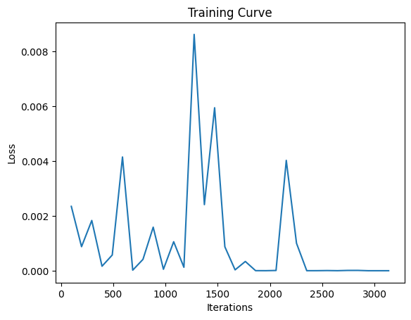

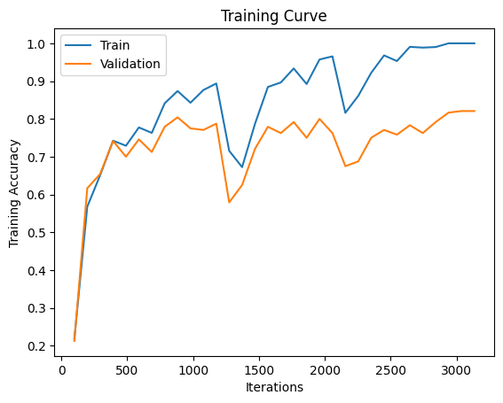

```
Final Training Accuracy: 1.0
Final Validation Accuracy: 0.8208333333333333
```

```python
# TO BE COMPLETED
hyperparameters = [(128, 0.01, 3), (512, 0.01, 3), (128, 0.005, 3), (512, 0.005, 3)]
result_pd = pd.DataFrame({'index': [], 'batch_size': [], 'learning_rate': [], 'kernel_size': [], 'train_acc': [], 'val_acc': []})

use_cuda = True  # Set to True if you want to use CUDA

for index, p in enumerate(hyperparameters):
    batch = p[0]
    lr = p[1]
    kernel = p[2]
    print(f"Model {index + 1} with hyperparameters: batch size: {batch}, learning rate: {lr}, layer 3 out channels: {kernel}")
    model = CNNClassifier(kernel_size=kernel)
    if use_cuda and torch.cuda.is_available():
        model.cuda()
        print('CUDA is available!  Training on GPU ...')
    else:
        print('CUDA is not available.  Training on CPU ...')

    final_train_acc, final_val_acc = train(model, train_loader, val_loader, batch_size=batch, lr=lr, num_epochs=32)
    result_pd = result_pd.append({'index': index + 1,'batch_size': batch,'learning_rate': lr,'kernel_size': kernel,'train_acc': final_train_acc,'val_acc': final_val_acc}, ignore_index=True)
```

```
CUDA is available!  Training on GPU ...
Epoch 1:  Train loss: 0.002733746077865362 |Train accuracy: 0.26738794435857804, Validation accuracy: 0.2833333333333333
Epoch 2:  Train loss: 0.001687552547082305 |Train accuracy: 0.5625965996908809, Validation accuracy: 0.5875
Epoch 3:  Train loss: 0.0027911013457924128 |Train accuracy: 0.6269963936115405, Validation accuracy: 0.6541666666666667
Epoch 4:  Train loss: 0.0001374559069518 |Train accuracy: 0.6913961875321999, Validation accuracy: 0.6958333333333333
Epoch 5:  Train loss: 0.00021592697885353118 |Train accuracy: 0.7099433281813499, Validation accuracy: 0.7166666666666667
Epoch 6:  Train loss: 0.00012103334302082658 |Train accuracy: 0.7434312210200927, Validation accuracy: 0.7625
Epoch 7:  Train loss: 0.0007698434637859464 |Train accuracy: 0.7145801133436372, Validation accuracy: 0.7166666666666667
Epoch 8:  Train loss: 0.0005659505259245634 |Train accuracy: 0.6707882534775889, Validation accuracy: 0.6541666666666667
Epoch 9:  Train loss: 3.485755587462336e-05 |Train accuracy: 0.8294693456980937, Validation accuracy: 0.7833333333333333
Epoch 10:  Train loss: 0.0043318686075508595 |Train accuracy: 0.8248325605358063, Validation accuracy: 0.75
Epoch 11:  Train loss: 0.0006192438304424286 |Train accuracy: 0.8614116434827409, Validation accuracy: 0.8125
Epoch 12:  Train loss: 0.0008906388538889587 |Train accuracy: 0.9124162802679031, Validation accuracy: 0.8083333333333333
Epoch 13:  Train loss: 3.7210450045677135e-06 |Train accuracy: 0.949510561566203, Validation accuracy: 0.8375
Epoch 14:  Train loss: 8.218749059096808e-08 |Train accuracy: 0.9685729005667182, Validation accuracy: 0.8333333333333334
Epoch 15:  Train loss: 3.7252867457482353e-09 |Train accuracy: 0.9592993302421432, Validation accuracy: 0.8125
Epoch 16:  Train loss: 4.676853222917998e-06 |Train accuracy: 0.9654817104585265, Validation accuracy: 0.8
Epoch 17:  Train loss: 1.82733117526368e-06 |Train accuracy: 0.9933024214322514, Validation accuracy: 0.8166666666666667
Epoch 18:  Train loss: 6.426019893979174e-08 |Train accuracy: 0.996393611540443, Validation accuracy: 0.8291666666666667
Epoch 19:  Train loss: 9.895051533703736e-08 |Train accuracy: 0.9953632148377125, Validation accuracy: 0.8166666666666667
Epoch 20:  Train loss: 3.680705731312628e-07 |Train accuracy: 0.996393611540443, Validation accuracy: 0.8083333333333333
Epoch 21:  Train loss: 0.0 |Train accuracy: 0.9974240082431737, Validation accuracy: 0.8291666666666667
Epoch 22:  Train loss: 5.355097254522434e-09 |Train accuracy: 1.0, Validation accuracy: 0.825
Epoch 23:  Train loss: 4.6566123179658803e-10 |Train accuracy: 1.0, Validation accuracy: 0.8333333333333334
Epoch 24:  Train loss: 4.6566123179658803e-10 |Train accuracy: 1.0, Validation accuracy: 0.8166666666666667
Epoch 25:  Train loss: 3.040531453279982e-07 |Train accuracy: 1.0, Validation accuracy: 0.8208333333333333
Epoch 26:  Train loss: 0.0 |Train accuracy: 1.0, Validation accuracy: 0.825
Epoch 27:  Train loss: 2.3283062977608182e-10 |Train accuracy: 1.0, Validation accuracy: 0.8208333333333333
Epoch 28:  Train loss: 2.5385318167536752e-06 |Train accuracy: 1.0, Validation accuracy: 0.8208333333333333
Epoch 29:  Train loss: 0.0 |Train accuracy: 1.0, Validation accuracy: 0.8208333333333333
Epoch 30:  Train loss: 1.396983417834008e-09 |Train accuracy: 1.0, Validation accuracy: 0.8208333333333333
Epoch 31:  Train loss: 1.3504130258468194e-08 |Train accuracy: 1.0, Validation accuracy: 0.8208333333333333
Epoch 32:  Train loss: 1.087016585188394e-06 |Train accuracy: 1.0, Validation accuracy: 0.825
```

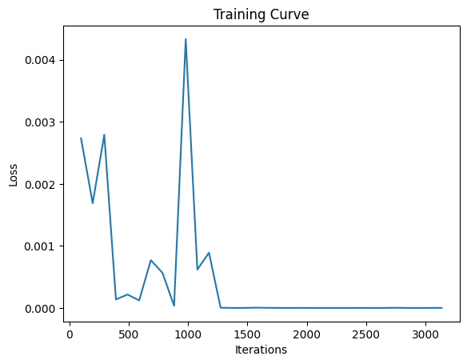

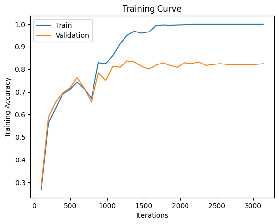

```
Final Training Accuracy: 1.0
Final Validation Accuracy: 0.825
```

```python
#tune kernel size = 5
class CNNClassifier2(nn.Module):
    def __init__(self, kernel_size=5):
        super(CNNClassifier2, self).__init__()
        self.name = 'CNN2'
        self.conv1 = nn.Conv2d(3, 32, kernel_size, padding=1)
        self.pool = nn.MaxPool2d(kernel_size=2, stride=2)
        self.conv2 = nn.Conv2d(32, 64, kernel_size, padding=1)
        self.fc1 = nn.Linear(54*54*64, 128)  # Corrected the input size
        self.fc2 = nn.Linear(128, 9)

    def forward(self, x):
        x = self.pool(F.relu(self.conv1(x)))
        x = self.pool(F.relu(self.conv2(x)))
        x = x.view(-1, 54*54*64)  # Corrected the view size
        x = F.relu(self.fc1(x))
        x = self.fc2(x)
        return x

model = CNNClassifier2(kernel_size=5)
if use_cuda and torch.cuda.is_available():
    model.cuda()
    print('CUDA is available!  Training on GPU ...')
else:
    print('CUDA is not available.  Training on CPU ...')

final_train_acc5, final_val_acc5 = train(model, train_loader, val_loader, batch_size=512, lr=0.005, num_epochs=32)
```

```
CUDA is available!  Training on GPU ...
Epoch 1:  Train loss: 0.003324339399114251 |Train accuracy: 0.43843379701184954, Validation accuracy: 0.4125
Epoch 2:  Train loss: 0.006613588891923428 |Train accuracy: 0.5146831530139103, Validation accuracy: 0.49583333333333335
Epoch 3:  Train loss: 0.0021674777381122112 |Train accuracy: 0.6697578567748583, Validation accuracy: 0.6541666666666667
Epoch 4:  Train loss: 0.005196998827159405 |Train accuracy: 0.6625450798557445, Validation accuracy: 0.6666666666666666
Epoch 5:  Train loss: 0.01611606776714325 |Train accuracy: 0.5739309634209171, Validation accuracy: 0.5625
Epoch 6:  Train loss: 0.00027567302458919585 |Train accuracy: 0.723338485316847, Validation accuracy: 0.6916666666666667
Epoch 7:  Train loss: 0.0072355857118964195 |Train accuracy: 0.7851622874806801, Validation accuracy: 0.7708333333333334
Epoch 8:  Train loss: 9.183029760606587e-06 |Train accuracy: 0.8268933539412674, Validation accuracy: 0.8083333333333333
Epoch 9:  Train loss: 0.005459113512188196 |Train accuracy: 0.8294693456980937, Validation accuracy: 0.7666666666666667
Epoch 10:  Train loss: 4.814789349438797e-07 |Train accuracy: 0.9000515198351365, Validation accuracy: 0.7916666666666666
Epoch 11:  Train loss: 0.003825913881883025 |Train accuracy: 0.848531684698609, Validation accuracy: 0.725
Epoch 12:  Train loss: 1.286050633098057e-06 |Train accuracy: 0.9361154044307058, Validation accuracy: 0.8125
Epoch 13:  Train loss: 7.543676616705852e-08 |Train accuracy: 0.9608449252962391, Validation accuracy: 0.7958333333333333
Epoch 14:  Train loss: 0.00012143822823418304 |Train accuracy: 0.9855744461617723, Validation accuracy: 0.8458333333333333
Epoch 15:  Train loss: 2.9591608836199157e-05 |Train accuracy: 0.9922720247295209, Validation accuracy: 0.8041666666666667
Epoch 16:  Train loss: 5.934145156061277e-05 |Train accuracy: 0.975785677485832, Validation accuracy: 0.7958333333333333
Epoch 17:  Train loss: 7.147424184950069e-06 |Train accuracy: 0.9891808346213292, Validation accuracy: 0.7958333333333333
Epoch 18:  Train loss: 4.889290607934527e-07 |Train accuracy: 0.9824832560535807, Validation accuracy: 0.7958333333333333
Epoch 19:  Train loss: 3.548258291630191e-07 |Train accuracy: 0.996393611540443, Validation accuracy: 0.8208333333333333
Epoch 20:  Train loss: 9.313225191043273e-10 |Train accuracy: 0.9902112313240597, Validation accuracy: 0.8166666666666667
Epoch 21:  Train loss: 0.0 |Train accuracy: 0.9979392065945389, Validation accuracy: 0.8375
Epoch 22:  Train loss: 8.949589391704649e-05 |Train accuracy: 1.0, Validation accuracy: 0.8333333333333334
Epoch 23:  Train loss: 1.1082659767680525e-07 |Train accuracy: 1.0, Validation accuracy: 0.8291666666666667
Epoch 24:  Train loss: 1.3969826184734302e-08 |Train accuracy: 1.0, Validation accuracy: 0.8291666666666667
Epoch 25:  Train loss: 8.775923197390512e-05 |Train accuracy: 1.0, Validation accuracy: 0.8291666666666667
Epoch 26:  Train loss: 0.0 |Train accuracy: 1.0, Validation accuracy: 0.8291666666666667
Epoch 27:  Train loss: 1.8626430176027498e-08 |Train accuracy: 1.0, Validation accuracy: 0.8291666666666667
Epoch 28:  Train loss: 0.0 |Train accuracy: 1.0, Validation accuracy: 0.8333333333333334
Epoch 29:  Train loss: 9.87139515018498e-07 |Train accuracy: 1.0, Validation accuracy: 0.8291666666666667
Epoch 30:  Train loss: 3.7252894102834944e-09 |Train accuracy: 1.0, Validation accuracy: 0.8333333333333334
Epoch 31:  Train loss: 0.0 |Train accuracy: 1.0, Validation accuracy: 0.8333333333333334
Epoch 32:  Train loss: 2.0356060304038692e-06 |Train accuracy: 1.0, Validation accuracy: 0.8333333333333334
```

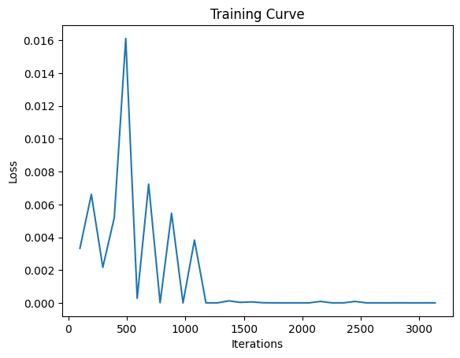

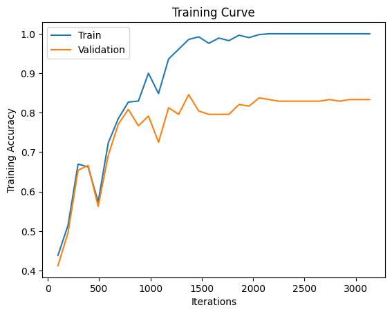

```
Final Training Accuracy: 1.0
Final Validation Accuracy: 0.8333333333333334
```

```python
model = CNNClassifier2(kernel_size=5)
if use_cuda and torch.cuda.is_available():
    model.cuda()
    print('CUDA is available!  Training on GPU ...')
else:
    print('CUDA is not available.  Training on CPU ...')

final_train_acc6, final_val_acc6 = train(model, train_loader, val_loader, batch_size=128, lr=0.005, num_epochs=32)

#append results
result_pd = result_pd.append({'index': 5,'batch_size': 512,'learning_rate': 0.005,'kernel_size': 5,'train_acc': final_train_acc5,'val_acc': final_val_acc5}, ignore_index=True)
result_pd = result_pd.append({'index': 6,'batch_size': 128,'learning_rate': 0.005,'kernel_size': 5,'train_acc': final_train_acc6,'val_acc': final_val_acc6}, ignore_index=True)
```

```
CUDA is available!  Training on GPU ...
Epoch 1:  Train loss: 0.017276408150792122 |Train accuracy: 0.19268418341061308, Validation accuracy: 0.2
Epoch 2:  Train loss: 0.016626466065645218 |Train accuracy: 0.24368882019577537, Validation accuracy: 0.275
Epoch 3:  Train loss: 0.011342351324856281 |Train accuracy: 0.422462648119526, Validation accuracy: 0.43333333333333335
Epoch 4:  Train loss: 0.01791226863861084 |Train accuracy: 0.48583204533745494, Validation accuracy: 0.4625
Epoch 5:  Train loss: 0.008766754530370235 |Train accuracy: 0.6213292117465224, Validation accuracy: 0.6125
Epoch 6:  Train loss: 0.002911738818511367 |Train accuracy: 0.5492014425553838, Validation accuracy: 0.5541666666666667
Epoch 7:  Train loss: 0.0043038735166192055 |Train accuracy: 0.6306027820710973, Validation accuracy: 0.6208333333333333
Epoch 8:  Train loss: 0.004409174434840679 |Train accuracy: 0.693456980937661, Validation accuracy: 0.7166666666666667
Epoch 9:  Train loss: 0.001598263275809586 |Train accuracy: 0.657908294693457, Validation accuracy: 0.6666666666666666
Epoch 10:  Train loss: 0.006943953689187765 |Train accuracy: 0.6707882534775889, Validation accuracy: 0.675
Epoch 11:  Train loss: 0.001401726622134447 |Train accuracy: 0.6960329726944874, Validation accuracy: 0.6916666666666667
Epoch 12:  Train loss: 0.006623932626098394 |Train accuracy: 0.7578567748583205, Validation accuracy: 0.7583333333333333
Epoch 13:  Train loss: 0.011366864666342735 |Train accuracy: 0.7387944358578052, Validation accuracy: 0.7541666666666667
Epoch 14:  Train loss: 0.004046195186674595 |Train accuracy: 0.7418856259659969, Validation accuracy: 0.7625
Epoch 15:  Train loss: 0.011229916475713253 |Train accuracy: 0.7712519319938176, Validation accuracy: 0.7416666666666667
Epoch 16:  Train loss: 0.000915353826712817 |Train accuracy: 0.7923750643997939, Validation accuracy: 0.7833333333333333
Epoch 17:  Train loss: 0.005376400891691446 |Train accuracy: 0.7717671303451829, Validation accuracy: 0.7541666666666667
Epoch 18:  Train loss: 7.70148471929133e-05 |Train accuracy: 0.8016486347243689, Validation accuracy: 0.7875
Epoch 19:  Train loss: 0.08188669383525848 |Train accuracy: 0.7011849562081401, Validation accuracy: 0.6458333333333334
Epoch 20:  Train loss: 0.011740623973309994 |Train accuracy: 0.7825862957238536, Validation accuracy: 0.7625
Epoch 21:  Train loss: 0.009752918034791946 |Train accuracy: 0.7563111798042246, Validation accuracy: 0.7583333333333333
Epoch 22:  Train loss: 0.005863106809556484 |Train accuracy: 0.7727975270479135, Validation accuracy: 0.775
Epoch 23:  Train loss: 0.0010320479050278664 |Train accuracy: 0.7928902627511591, Validation accuracy: 0.7625
Epoch 24:  Train loss: 0.00617795018479228 |Train accuracy: 0.8181349819680577, Validation accuracy: 0.775
Epoch 25:  Train loss: 0.011074776761233807 |Train accuracy: 0.758887171561051, Validation accuracy: 0.7333333333333333
Epoch 26:  Train loss: 0.014768333174288273 |Train accuracy: 0.7357032457496137, Validation accuracy: 0.6333333333333333
Epoch 27:  Train loss: 2.7519554350874387e-05 |Train accuracy: 0.8258629572385369, Validation accuracy: 0.7791666666666667
Epoch 28:  Train loss: 0.0001284433965338394 |Train accuracy: 0.8572900566718187, Validation accuracy: 0.7916666666666666
Epoch 29:  Train loss: 0.0005386988632380962 |Train accuracy: 0.8526532715095312, Validation accuracy: 0.7833333333333333
Epoch 30:  Train loss: 0.0003495824057608843 |Train accuracy: 0.8578052550231839, Validation accuracy: 0.7958333333333333
Epoch 31:  Train loss: 0.00032546697184443474 |Train accuracy: 0.8964451313755796, Validation accuracy: 0.8
Epoch 32:  Train loss: 0.015153088606894016 |Train accuracy: 0.9057187017001546, Validation accuracy: 0.8041666666666667
```

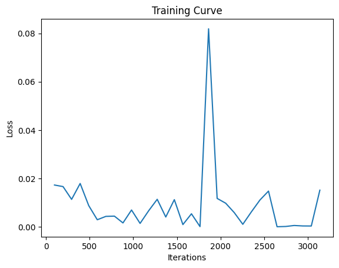

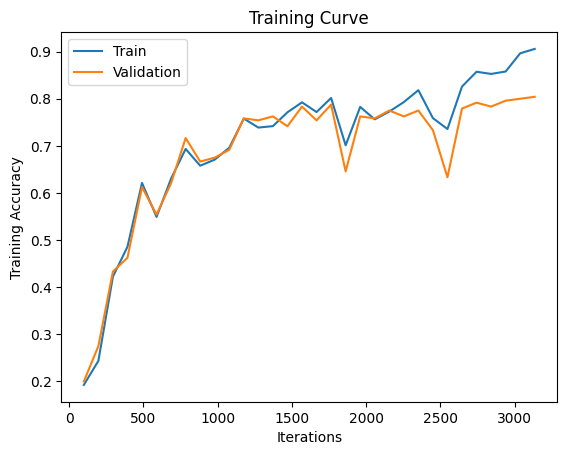

```
Final Training Accuracy: 0.9057187017001546
Final Validation Accuracy: 0.8041666666666667
```

```python
model = CNNClassifier2(kernel_size=5)
if use_cuda and torch.cuda.is_available():
    model.cuda()
    print('CUDA is available!  Training on GPU ...')
else:
    print('CUDA is not available.  Training on CPU ...')

final_train_acc7, final_val_acc7 = train(model, train_loader, val_loader, batch_size=128, lr=0.001, num_epochs=32)

#append results

result_pd = result_pd.append({'index': 7,'batch_size': 128,'learning_rate': 0.001,'kernel_size': 5,'train_acc': final_train_acc7,'val_acc': final_val_acc7}, ignore_index=True)
```

```
CUDA is available!  Training on GPU ...
Epoch 1:  Train loss: 0.01696057803928852 |Train accuracy: 0.15352910870685213, Validation accuracy: 0.14166666666666666
Epoch 2:  Train loss: 0.016155244782567024 |Train accuracy: 0.2539927872230809, Validation accuracy: 0.25
Epoch 3:  Train loss: 0.02353198081254959 |Train accuracy: 0.22668727460072127, Validation accuracy: 0.2375
Epoch 4:  Train loss: 0.01296435110270977 |Train accuracy: 0.366306027820711, Validation accuracy: 0.35833333333333334
Epoch 5:  Train loss: 0.012878380715847015 |Train accuracy: 0.5548686244204019, Validation accuracy: 0.5125
Epoch 6:  Train loss: 0.004101741127669811 |Train accuracy: 0.5224111282843895, Validation accuracy: 0.5
Epoch 7:  Train loss: 0.006204536650329828 |Train accuracy: 0.631633178773828, Validation accuracy: 0.6416666666666667
Epoch 8:  Train loss: 0.0026793046854436398 |Train accuracy: 0.6527563111798043, Validation accuracy: 0.6791666666666667
Epoch 9:  Train loss: 0.0017752149142324924 |Train accuracy: 0.6620298815043791, Validation accuracy: 0.6583333333333333
Epoch 10:  Train loss: 0.0008497150847688317 |Train accuracy: 0.6388459556929418, Validation accuracy: 0.6416666666666667
Epoch 11:  Train loss: 0.0011230247328057885 |Train accuracy: 0.5826893353941267, Validation accuracy: 0.6208333333333333
Epoch 12:  Train loss: 0.0006836566026322544 |Train accuracy: 0.6800618238021638, Validation accuracy: 0.6958333333333333
Epoch 13:  Train loss: 0.005777188576757908 |Train accuracy: 0.6980937660999484, Validation accuracy: 0.6916666666666667
Epoch 14:  Train loss: 0.005494995042681694 |Train accuracy: 0.7094281298299846, Validation accuracy: 0.7416666666666667
Epoch 15:  Train loss: 0.0013168049044907093 |Train accuracy: 0.7047913446676971, Validation accuracy: 0.7125
Epoch 16:  Train loss: 0.0036315026227384806 |Train accuracy: 0.7434312210200927, Validation accuracy: 0.7333333333333333
Epoch 17:  Train loss: 0.027479328215122223 |Train accuracy: 0.7619783616692427, Validation accuracy: 0.7541666666666667
Epoch 18:  Train loss: 0.0037675865460187197 |Train accuracy: 0.7310664605873262, Validation accuracy: 0.7625
Epoch 19:  Train loss: 0.01612994819879532 |Train accuracy: 0.7269448737764039, Validation accuracy: 0.7083333333333334
Epoch 20:  Train loss: 0.02841905876994133 |Train accuracy: 0.7743431221020093, Validation accuracy: 0.7666666666666667
Epoch 21:  Train loss: 0.0009428027551621199 |Train accuracy: 0.732612055641422, Validation accuracy: 0.7041666666666667
Epoch 22:  Train loss: 0.00687318155542016 |Train accuracy: 0.749613601236476, Validation accuracy: 0.7458333333333333
Epoch 23:  Train loss: 0.004621410742402077 |Train accuracy: 0.7789799072642968, Validation accuracy: 0.7583333333333333
Epoch 24:  Train loss: 3.5221335565438494e-05 |Train accuracy: 0.7877382792375064, Validation accuracy: 0.7666666666666667
Epoch 25:  Train loss: 0.006497105583548546 |Train accuracy: 0.8052550231839258, Validation accuracy: 0.7583333333333333
Epoch 26:  Train loss: 0.009302785620093346 |Train accuracy: 0.8078310149407522, Validation accuracy: 0.7833333333333333
Epoch 27:  Train loss: 0.0015205828240141273 |Train accuracy: 0.8320453374549202, Validation accuracy: 0.8083333333333333
Epoch 28:  Train loss: 7.588692824356258e-05 |Train accuracy: 0.8068006182380216, Validation accuracy: 0.75
Epoch 29:  Train loss: 0.0029622246511280537 |Train accuracy: 0.8155589902112313, Validation accuracy: 0.7958333333333333
Epoch 30:  Train loss: 2.6422523660585284e-05 |Train accuracy: 0.839258114374034, Validation accuracy: 0.7791666666666667
Epoch 31:  Train loss: 0.004905592184513807 |Train accuracy: 0.8263781555899021, Validation accuracy: 0.75
Epoch 32:  Train loss: 0.0004999936791136861 |Train accuracy: 0.8397733127253992, Validation accuracy: 0.8
```

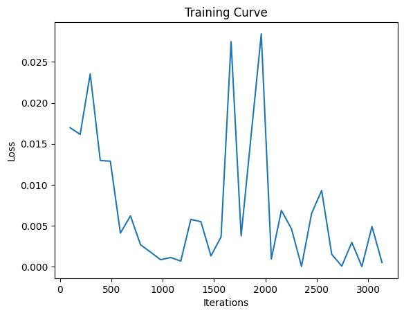

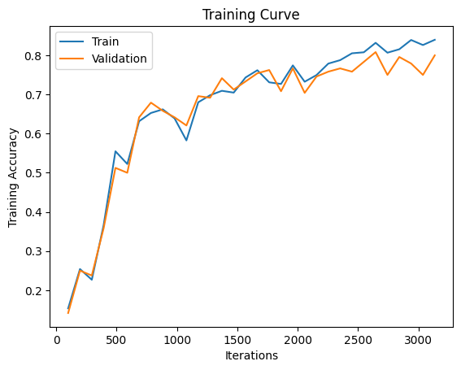

```
Final Training Accuracy: 0.8397733127253992
Final Validation Accuracy: 0.8
```

```python
model = CNNClassifier(kernel_size=3)
if use_cuda and torch.cuda.is_available():
    model.cuda()
    print('CUDA is available!  Training on GPU ...')
else:
    print('CUDA is not available.  Training on CPU ...')

final_train_acc8, final_val_acc8 = train(model, train_loader, val_loader, batch_size=128, lr=0.001, num_epochs=32)

#append results
result_pd = result_pd.append({'index': 8,'batch_size': 128,'learning_rate': 0.001,'kernel_size': 3,'train_acc': final_train_acc8,'val_acc': final_val_acc8}, ignore_index=True)
```

### Part (iii) - [2pt DISCUSSION]

Choose the best model out of all the ones that you have trained. Justify your choice.

```python
result_pd
```

[output not shown]

```python
'''
PROVIDE YOUR ANSWER BELOW
The best model: batch_size 128, learning rate 0.005, kernel size 3, with highest validation accuracy.

'''
```

### Part (iv) - [2pt RESULTS]

Report the test accuracy of your best model. You should only do this step once and prior to this step you should have only used the training and validation data.

```python
# TO BE COMPLETED
best_model = CNNClassifier(kernel_size=3)
model_path = '/content/model_CNN_bs128_lr0.005_epoch32'
state = torch.load(model_path)
best_model.load_state_dict(state)

correct = 0
total = 0
for imgs, labels in test_loader: # test data

  #To Enable GPU Usage
  if use_cuda and torch.cuda.is_available():
    imgs = imgs.cuda()
    labels = labels.cuda()

  output = model(imgs)
  #select index with maximum prediction score
  pred = output.max(1, keepdim=True)[1]
  correct += pred.eq(labels.view_as(pred)).sum().item()
  total += imgs.shape[0]

test_accuracy = correct / total
print('Test Accuracy:', test_accuracy)
```

```
Test Accuracy: 0.744
```

```python
'''
PROVIDE YOUR ANSWER BELOW


Test accuracy is 74.4%



'''
```

## Part 4. Transfer Learning [8pt]

For many image classification tasks, it is generally not a good idea to train a very large deep neural network model from scratch due to the enormous compute requirements and lack of sufficient amounts of training data.

One of the better options is to try using an existing model that performs a similar task to the one you need to solve. This method of utilizing a pre-trained network for other similar tasks is broadly termed **Transfer Learning**. In this assignment, we will use Transfer Learning to extract features from the hand gesture images. Then, train a smaller network to use these features as input and classify the hand gestures.

As you have learned from the CNN lecture, convolution layers extract various features from the images which get utilized by the fully connected layers for correct classification. AlexNet architecture played a pivotal role in establishing Deep Neural Nets as a go-to tool for image classification problems and we will use an ImageNet pre-trained AlexNet model to extract features in this assignment.

### Part (i) - [2pt EXPLORATORY]

Here is the code to load the AlexNet network, with pretrained weights. When you first run the code, PyTorch will download the pretrained weights from the internet.

```python
import torchvision.models
alexnet = torchvision.models.alexnet(pretrained=True)
```

The alexnet model is split up into two components: *alexnet.features* and *alexnet.classifier*. The first neural network component, *alexnet.features*, is used to compute convolutional features, which are taken as input in *alexnet.classifier*.

The neural network alexnet.features expects an image tensor of shape Nx3x224x224 as input and it will output a tensor of shape Nx256x6x6 . (N = batch size).

Compute the AlexNet features for each of your training, validation, and test data. Here is an example code snippet showing how you can compute the AlexNet features for some images (your actual code might be different):

```python
# img = ... a PyTorch tensor with shape [N,3,224,224] containing hand images ...
# features = alexnet.features(img)
```

**Save the computed features**. You will be using these features as input to your neural network in Part (ii), and you do not want to re-compute the features every time. Instead, run *alexnet.features* once for each image, and save the result.

```python
# TO BE COMPLETED
batch_size  = 32
num_workers = 0

train_loader = torch.utils.data.DataLoader(train_data, batch_size=batch_size ,num_workers=num_workers, shuffle=True)
val_loader = torch.utils.data.DataLoader(val_data, batch_size=batch_size ,num_workers=num_workers, shuffle=True)
test_loader = torch.utils.data.DataLoader(test_data, batch_size=batch_size ,num_workers=num_workers, shuffle=True)

if os.path.exists('Alexnet'):
    shutil.rmtree('Alexnet')
os.makedirs('Alexnet')

#alexnet.features once for each image, and save the result
alex_train_feature = []
for img, label in iter(train_loader):
    features = alexnet.features(img)
    alex_train_feature.append((features, label))
torch.save(alex_train_feature, 'Alexnet/train_features.pth')

alex_val_features = []
for img, label in iter(val_loader):
    features = alexnet.features(img)
    alex_val_features.append((features, label))
torch.save(alex_val_features, 'Alexnet/val_features.pth')

alex_test_features = []
for imgs, label in iter(test_loader):
    features = alexnet.features(imgs)
    alex_test_features.append((features, label))
torch.save(alex_test_features, 'Alexnet/test_features.pth')
```

### Part (ii) - [2pt MODEL]

Build a convolutional neural network model that takes as input these AlexNet features, and makes a prediction. Your model should be a subclass of nn.Module.

Explain your choice of neural network architecture: how many layers did you choose? What types of layers did you use: fully-connected or convolutional? What about other decisions like pooling layers, activation functions, number of channels / hidden units in each layer?

Here is an example of how your model may be called:

```python
# features = ... load precomputed alexnet.features(img) ...
#output = model(features)
#prob = F.softmax(output)
```

```python
class AlexNetClassifier(nn.Module):
    def __init__(self):
        super(AlexNetClassifier, self).__init__()
        self.name = "AlexNetClassifier"
        self.fc1 = nn.Linear(256 * 6 * 6, 32)
        self.fc2 = nn.Linear(32, 9)

    def forward(self, x):
        x = x.view(-1, 256 * 6 * 6) #flatten feature data
        x = F.relu(self.fc1(x))
        x = self.fc2(x)
        return x
```

```python
'''
PROVIDE YOUR ANSWER BELOW

Two fully connected layers are used.
First fully connected layer transforms the flattened input from a 256 * 6 * 6 dimension to a 32 dimension.
Second fully connected layer transforms the 32-dimensional vector to a 9-dimensional output.
Relu as activation function after the first fully connected layer

Number of hidden units: 32

'''
```

### Part (iii) - [1pt MODEL]

Train your new network, including any hyperparameter tuning. Plot and submit the training curve of your best model only.

Note: Depending on how you are caching (saving) your AlexNet features, PyTorch might still be tracking updates to the **AlexNet weights**, which we are not tuning. One workaround is to convert your AlexNet feature tensor into a numpy array, and then back into a PyTorch tensor.

```python
#tensor = torch.from_numpy(tensor.detach().numpy())
```

```python
# TO BE COMPLETED
# get load the data
train_loader = torch.load('Alexnet/train_features.pth')
val_loader = torch.load('Alexnet/val_features.pth')
test_loader = torch.load('Alexnet/test_features.pth')
```

```
CUDA is available!  Training on GPU ...
Epoch 1:  Train loss: 0.0035291225649416447 |Train accuracy: 0.8181349819680577, Validation accuracy: 0.7875
Epoch 2:  Train loss: 0.00143875228241086 |Train accuracy: 0.9026275115919629, Validation accuracy: 0.8583333333333333
Epoch 3:  Train loss: 0.0014084273716434836 |Train accuracy: 0.9598145285935085, Validation accuracy: 0.9208333333333333
Epoch 4:  Train loss: 0.00022764221648685634 |Train accuracy: 0.9747552807831015, Validation accuracy: 0.9208333333333333
Epoch 5:  Train loss: 0.00024068643688224256 |Train accuracy: 0.9778464708912932, Validation accuracy: 0.9291666666666667
Epoch 6:  Train loss: 0.0003853871312458068 |Train accuracy: 0.9582689335394127, Validation accuracy: 0.9
Epoch 7:  Train loss: 0.00023932319891173393 |Train accuracy: 0.9314786192684184, Validation accuracy: 0.8625
Epoch 8:  Train loss: 3.622660369728692e-05 |Train accuracy: 0.996393611540443, Validation accuracy: 0.9333333333333333
Epoch 9:  Train loss: 7.330691005336121e-05 |Train accuracy: 0.985059247810407, Validation accuracy: 0.9
Epoch 10:  Train loss: 3.189893686794676e-05 |Train accuracy: 0.9927872230808862, Validation accuracy: 0.9208333333333333
Epoch 11:  Train loss: 1.7829148418968543e-05 |Train accuracy: 0.9984544049459042, Validation accuracy: 0.9416666666666667
Epoch 12:  Train loss: 4.876549792243168e-05 |Train accuracy: 0.9979392065945389, Validation accuracy: 0.9333333333333333
Epoch 13:  Train loss: 2.4296185074490495e-05 |Train accuracy: 0.9994848016486347, Validation accuracy: 0.95
Epoch 14:  Train loss: 2.429625965305604e-05 |Train accuracy: 0.9994848016486347, Validation accuracy: 0.95
Epoch 15:  Train loss: 2.813706305460073e-05 |Train accuracy: 0.9994848016486347, Validation accuracy: 0.95
Epoch 16:  Train loss: 1.8355483916820958e-05 |Train accuracy: 0.9994848016486347, Validation accuracy: 0.95
Epoch 17:  Train loss: 9.961182513507083e-06 |Train accuracy: 1.0, Validation accuracy: 0.9541666666666667
Epoch 18:  Train loss: 8.315222657984123e-06 |Train accuracy: 1.0, Validation accuracy: 0.9541666666666667
Epoch 19:  Train loss: 8.05264699010877e-06 |Train accuracy: 1.0, Validation accuracy: 0.9541666666666667
Epoch 20:  Train loss: 7.438609372911742e-06 |Train accuracy: 1.0, Validation accuracy: 0.95
Epoch 21:  Train loss: 6.983281764405547e-06 |Train accuracy: 1.0, Validation accuracy: 0.95
Epoch 22:  Train loss: 6.457231393142138e-06 |Train accuracy: 1.0, Validation accuracy: 0.95
Epoch 23:  Train loss: 6.154510629130527e-06 |Train accuracy: 1.0, Validation accuracy: 0.95
Epoch 24:  Train loss: 6.088117515901104e-06 |Train accuracy: 1.0, Validation accuracy: 0.9541666666666667
Epoch 25:  Train loss: 5.541248356166761e-06 |Train accuracy: 1.0, Validation accuracy: 0.9583333333333334
Epoch 26:  Train loss: 5.224685537541518e-06 |Train accuracy: 1.0, Validation accuracy: 0.9583333333333334
Epoch 27:  Train loss: 5.031462023907807e-06 |Train accuracy: 1.0, Validation accuracy: 0.9583333333333334
Epoch 28:  Train loss: 4.835276740777772e-06 |Train accuracy: 1.0, Validation accuracy: 0.9583333333333334
Epoch 29:  Train loss: 4.7258972699637525e-06 |Train accuracy: 1.0, Validation accuracy: 0.9541666666666667
Epoch 30:  Train loss: 4.393618382891873e-06 |Train accuracy: 1.0, Validation accuracy: 0.9541666666666667
Epoch 31:  Train loss: 4.257303771737497e-06 |Train accuracy: 1.0, Validation accuracy: 0.9541666666666667
Epoch 32:  Train loss: 4.161865945206955e-06 |Train accuracy: 1.0, Validation accuracy: 0.9541666666666667
```

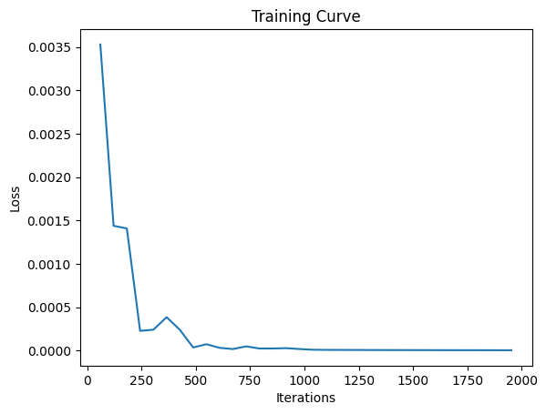

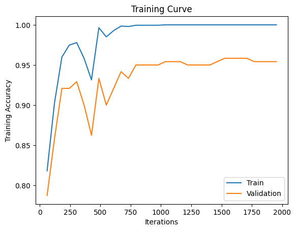

```
Final Training Accuracy: 1.0
Final Validation Accuracy: 0.9541666666666667
```

```python
use_cuda = True
model = AlexNetClassifier()
if use_cuda and torch.cuda.is_available():
    model.cuda()
    print('CUDA is available!  Training on GPU ...')
else:
    print('CUDA is not available.  Training on CPU ...')

train_acc_alex, val_acc_alex = train(model, train_loader, val_loader, batch_size=64, lr=0.005, num_epochs=32)
```

### Part (iv) - [2pt RESULTS]

Report the test accuracy of your best model. How does the test accuracy compare to Part 3(iv) without transfer learning?

```python
# TO BE COMPLETED

best_model = AlexNetClassifier()
model_path = '/content/model_AlexNetClassifier_bs64_lr0.005_epoch27'
state = torch.load(model_path)
best_model.load_state_dict(state)

if use_cuda and torch.cuda.is_available():
  best_model.cuda()

correct = 0
total = 0
for imgs, labels in test_loader: # test data
  #To Enable GPU Usage
  if use_cuda and torch.cuda.is_available():
    imgs = imgs.cuda()
    labels = labels.cuda()

  output = model(imgs)
  pred = output.max(1, keepdim=True)[1]
  correct += pred.eq(labels.view_as(pred)).sum().item()
  total += imgs.shape[0]

test_accuracy = correct / total
print('Test Accuracy:', test_accuracy)
```

```
Test Accuracy: 0.916
```

```python
'''
PROVIDE YOUR ANSWER BELOW

Test accuracy of the best model : 91.6%.

How does the test accuracy compare to Part 3(iv) without transfer learning?
The test accuracy increased from 74.4% to 91.6%.




'''
```